# Visualiser af antal sagte ord

Før vi begynder, skal vi indlæse de udvidelsespakker til R, som vi vil benytte. Til sidst i denne kodeblok indlæser vi også de R funktioner vi har skrevet til dette projekt ved at `source` filen `src/p017-functions.R`.

```r
library(tidyverse)
library(here)
library(ndjson)
library(xslt)
library(fs)
library(ggplot2)

require(readr)  # for read_csv()
require(purrr)  # for map(), reduce()

source(here("src/p017-functions.R"))
```

# Indlæs data

Vi kan nu benytte en af P017 funktionerne til at indlæse alle de Holberg stykker, som vi har liggende i `test-data` mappen.

```r
read_plays_jsonl(here("test-data")) -> plays
```

For at gøre det nemme for os selv, starter vi med kun at se på Barselstuen

```r
barselsstuen <- plays %>%
  filter(title == " Barselsstuen")
```

# Gør data klar til visualisering

I et skuespil lader vi scene være den tidsmæssige udvikling. Så vi tæller hvad hver rolle siger for hver scene.

Hvor mange dialoger er der pr. scene?

```r
barselsstuen %>%
  count(act_number, scene_number)
```

| act_number | scene_number | n |
| --- | --- | --- |
| 1 | 1 | 6 |
| 1 | 2 | 18 |
| 1 | 3 | 32 |
| 1 | 4 | 6 |
| 1 | 5 | 15 |
| 1 | 6 | 21 |
| 1 | 7 | 46 |
| 2 | 1 | 27 |
| 2 | 2 | 41 |
| 2 | 3 | 47 |

[output cut: 34 more lines]

## Tilføj scene indeks

Da vi ønsker at visualisere, hvor meget der tales over tid, har vi brug for et tal, der repræsenterer denne tid. Dette tal lader vi være et indeks for hver scene, som vi beregner i det følgende.

Først skal vi have beregnet antallet af scener i hver akt. Det gøres med følgende kode.

```r
barselsstuen %>%
   group_by(act_number)  %>%
   summarise(scenes = max(scene_number)) %>%
   pull(scenes) %>% cumsum() -> act_length

act_length
```

```
[1]  7 21 28 37 44
```

`act_length` er nu en liste, hvor element *i* angiver hvor mange scener der har været til og med akt *i*. Fx er det tredje element i listen 28, hvilket betyder, at der i akt 1 til 3 sammenlagt er 28 scener.

Vi kan nu lave en funktion, som givet et aktnummer og scenenummer kan beregne den givne scenes nummer i sekvensen af alle scener

```r
calc_scene_index <- function(act_number, scene_number, act_length) {
   ifelse(is.numeric(scene_number),
      scene_number + ifelse(act_number==1, 0, act_length[act_number-1]),
      NA
   )
}
```

Vi bruger den som følger til at finde fx hvilket indeks den 4. scene i akt 3 har

```r
calc_scene_index(3, 4, act_length)
```

```
[1] 25
```

# Visualiser

For at visualisere hvem der siger hvor meget i de enkelte scener, skal vi erstatte det sagte med hvor mange ord, der bliver sagt. Dette gør vi ved at benytte funktionen `str_count(spoke, '\\w+')` som tager `spoke` og tæller hvor mange ord, der er i `spoke`. Denne værdi tilføjer vi i en ny kolonne, som vi kalder `n_spoken_words`.

```r
barselsstuen %>%
  mutate(n_spoken_words = str_count(spoke, '\\w+')) %>%
  select(n_spoken_words, everything())
```

| n_spoken_words | abrTitle | abrYear | act | act_number | index | scene | scene_number | stage | title | year | speaker | spoke | speaker_stage |
| --- | --- | --- | --- | --- | --- | --- | --- | --- | --- | --- | --- | --- | --- |
| NA | Barselsstuen Komedie | (1724) | Første akt | 1 | 1 | Scene 1 | 1 | NA | Barselsstuen | (1724) | Troels | NA | ( tager op et stykke smalt papir men så langt som det hele theatrum) |
| 167 | Barselsstuen Komedie | (1724) | Første akt | 1 | 1 | Scene 1 | 1 | NA | Barselsstuen | (1724) | Troels | Maren Hansdatter, Barbara Per Nielsens, Abelone Hans Hansens, Christine Erik Eriksens, Engelke Jens Hattemagers, Lusse Frands Buntmagers, Vibeke Per Guldbrandsens, Maren Christopher Skrædders, Elsebet… | NA |
| 273 | Barselsstuen Komedie | (1724) | Første akt | 1 | 2 | Scene 1 | 1 | NA | Barselsstuen | (1724) | Troels | Skal man giftes, må der lige så mange folk komme sammen for at æde og drikke op mere end en stakkels håndværksmand kan fortjene i fire år igen. Derfor har man hittet på den mode i gamle dage at den ha… | NA |
| 253 | Barselsstuen Komedie | (1724) | Første akt | 1 | 3 | Scene 1 | 1 | NA | Barselsstuen | (1724) | Troels | Vil jeg begive mig fra bryllupper til begravelser, da finder jeg lige så megen galskab ved de sidste som ved de første. En stakkels kone mister sin mand, som jeg sætter efterlader hende nogle skilling… | NA |
| 100 | Barselsstuen Komedie | (1724) | Første akt | 1 | 4 | Scene 1 | 1 | NA | Barselsstuen | (1724) | Troels | Men disse barselsstuer er rent ravgale. Her skal først et hundrede mennesker gives til kende som et stort vidunder at Hans Hansen eller Jespersen har gjort det mesterstykke ved sin kone som enhver bon… | NA |
| 17 | Barselsstuen Komedie | (1724) | Første akt | 1 | 5 | Scene 1 | 1 | NA | Barselsstuen | (1724) | Troels | Men hvem pokker er det som kommer så løbende? Det er Christophersens karl. Hvad mon han vil? | NA |
| NA | Barselsstuen Komedie | (1724) | Første akt | 1 | 1 | Scene 2 | 2 | Claus, Troels | Barselsstuen | (1724) | NA | NA | NA |
| 11 | Barselsstuen Komedie | (1724) | Første akt | 1 | 1 | Scene 2 | 2 | NA | Barselsstuen | (1724) | Claus | Ak, kære Troels, veksl mig en toskilling for to eneste skillinger! | NA |
| 7 | Barselsstuen Komedie | (1724) | Første akt | 1 | 2 | Scene 2 | 2 | NA | Barselsstuen | (1724) | Troels | Hvad vil du med de eneste skillinger? | NA |
| 12 | Barselsstuen Komedie | (1724) | Første akt | 1 | 3 | Scene 2 | 2 | NA | Barselsstuen | (1724) | Claus | Jeg vil give en for at komme op i det runde tårn. | NA |

[output cut: 990 more lines]

Vi er nu ved at være klar til at visualisere, hvem der siger hvor meget i Barselsstuen. Vi mangler bare at kombinere ovenstående kode

```r
barselsstuen %>%
  # add a scene index for the x-axis
  rowwise() %>%
  mutate(scene_index = calc_scene_index(act_number, scene_number, act_length)) %>%
  # remove rows that are not dialogue
  filter(act != "", scene != "", !is.na(spoke)) %>%

  # select only the columns, that we are interested in
  select(scene_index, speaker, spoke) %>%

  # add the number of spoken words
  mutate(n_spoken_words = str_count(spoke, '\\w+')) %>%
  # remove the spoken words
  select(-spoke) %>%

  # group the play in scene_index and speaker, ignoring the test
  group_by(scene_index, speaker) %>%
  # Ensure that each speaker only appears once in each scene, i.e. sum the words spoken by each speaker
  # Lastly store the new data frame in a new reference for later use
  summarise(words = sum(n_spoken_words)) -> barselsstuen_vis
#print(barselsstuen_vis, n=60)
barselsstuen_vis
```

| scene_index | speaker | words |
| --- | --- | --- |
| 1 | Troels | 810 |
| 2 | Claus | 180 |
| 2 | Troels | 198 |
| 3 | Corfitz | 255 |
| 3 | Troels | 318 |
| 3 | Trols | 12 |
| 4 | Corfitz | 311 |
| 5 | Corfitz | 158 |
| 5 | Jeronimus | 129 |
| 6 | Corfitz | 358 |

[output cut: 127 more lines]

Vi kan nu bruge `barselsstuen_vis` som input til R’s visualiseringssystem, som hedder `ggplot`

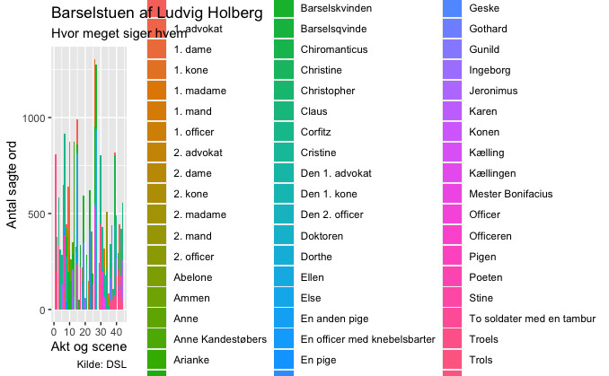

```r
barselsstuen_vis %>%
  ggplot(aes(fill = speaker, y = words, x = scene_index)) +
    geom_bar(position="stack", stat="identity") +
    labs(
      title = "Barselstuen af Ludvig Holberg",
      subtitle = "Hvor meget siger hvem",
      caption = "Kilde: DSL",
      fill = "Rolle"
    ) +
  xlab("Akt og scene") +
  ylab("Antal sagte ord")
```

## Sammenlæg forskellige stavemåde af samme rolle

I ovenstående diagram ser vi, at flere roller optræder med flere stavemåder. Det kan vi heldigvis nemt håndtere.

Først laver vi en liste over alle roller i Barselsstuen

```r
print(barselsstuen_vis %>%
        ungroup() %>%
  select(speaker) %>%
  distinct(speaker) %>%
  arrange(speaker), n=60)
```

| speaker |
| --- |
| 1. advokat |
| 1. dame |
| 1. kone |
| 1. madame |
| 1. mand |
| 1. officer |
| 2. advokat |
| 2. dame |
| 2. kone |

[output cut: 47 more lines]

Vi kan nu bruge to R funktioner: `if_else()` og `%in%`. Den første har tre argumenter. Det første er et logisk udtryk. Hvis dette udtryk er sandt, returneres resultatet af det andet argument. Hvis udtrykket er falsk, returneres resultatet af det tredje argument. Fx

```r
if_else(2==2, "Korrekt", "FAKE NEWS")
```

```
[1] "Korrekt"
```

```r
if_else("Trump"=="Klog", "Korrekt", "FAKE NEWS")
```

```
[1] "FAKE NEWS"
```

Vi vil også benytte funktionen `%in%`, som tjekker for om det der står til venstre er indeholdt i den liste der står til højre. Fx

```r
12 %in% c(1,2,3,4)
```

```
[1] FALSE
```

```r
12 %in% c(1, 2, 3, 12, 24)
```

```
[1] TRUE
```

Men det to funktioner, kan vi nu skrive denne kode

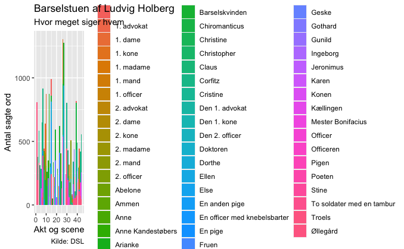

```r
barselsstuen_vis %>%
  ungroup() %>%

  # count all versions of Troels as one
  mutate(
    speaker = if_else(speaker %in% c("Troels", "Trols"), "Troels", speaker)) %>%

  # count all versions of Barselskvinden as one
  mutate(
    speaker = if_else(speaker %in% c("Barselskonen", "Barselskvinden", "Barselsqvinde"), "Barselskvinden", speaker)) %>%

  # Count all versions of kællingen as one
  mutate(
    speaker = if_else(speaker %in% c("Kælling", "Kællingen"), "Kællingen", speaker)) %>%

  ggplot(aes(fill = speaker, y = words, x = scene_index)) +
    geom_bar(position="stack", stat="identity") +
    labs(
      title = "Barselstuen af Ludvig Holberg",
      subtitle = "Hvor meget siger hvem",
      caption = "Kilde: DSL",
      fill = "Rolle"
    ) +
  xlab("Akt og scene") +
  ylab("Antal sagte ord")
```